# Subjective Question

### Question:

#### What is the optimal value of alpha for ridge and lasso regression? What will be the changes in the model if you choose double the value of alpha for both ridge and lasso? What will be the most important predictor variables after the change is implemented?

### Answer :

#### Ridge Regression : optimal lambda : 10 , on double the value of alpha i.e. 20 train r2 score decreases from 87 to 86 and test r2 score decreases from 85 to 84

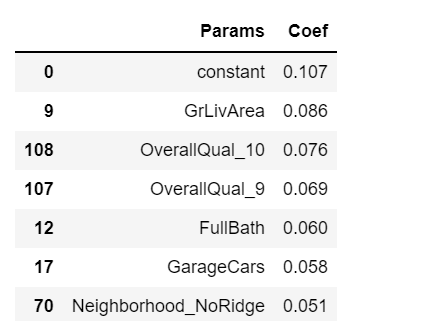

with alpha 20:

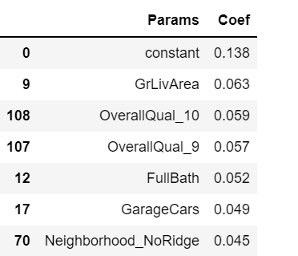

it shows that top feature remain same but coefficent get changed

#### Lasso Regression : optimal lambda : 0.001 on double the value of alpha i.e. 0.002 train r2 score decreases from 83 to 77 and test r2 score decreases from 81 to 77

Top 10 feature of Lasso with alpha .001:

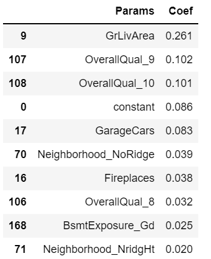

with alpha .002:

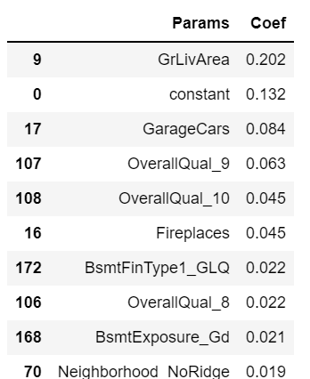

it shows that top feature get changed as well coefficent also get changed

### Question:

#### You have determined the optimal value of lambda for ridge and lasso regression during the assignment. Now, which one will you choose to apply and why?

#### Optimal value for lambda is chossen on best param value of the lambda based on the GridCV and estimator r2 ( gridCV will give mean r2 score across the n Fold) , we also analyse the Train & test score of the model based on the the lambda value selected ( optimal value), and it should not vary much as it may lead to underfit or overfit.

#### best param : model_cv.best*params*

#### best score : model_cv.best*score*

Ridge Regression : optimal lambda : 10 && Lasso Regression : optimal lambda : 0.001

### Question:

#### After building the model, you realised that the five most important predictor variables in the lasso model are not available in the incoming data. You will now have to create another model excluding the five most important predictor variables. Which are the five most important predictor variables now?

#### Answer:

Five most imp variable in Lasso with lambda 0.001 is 'GrLivArea','OverallQual_9','OverallQual_10','GarageCars','Neighborhood_NoRidge'

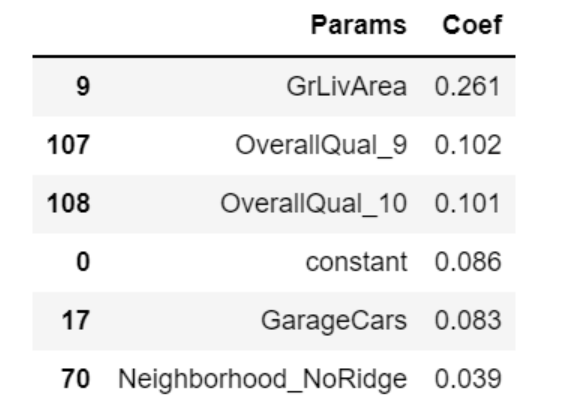

Lets remove these variable and rebuild the lasso model and next set of five most imp feature is

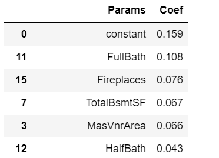

### Question:

#### How can you make sure that a model is robust and generalisable? What are the implications of the same for the accuracy of the model and why?

#### Answer :

Regularization helps to avoid overfiiting as well underfitting, keeping bias & variance trade off at its best.

#### A model that exhibits small variance and high bias will underfit the target, while a model with high variance and little bias will overfit the target. A model with high variance may represent the data set accurately but could lead to overfitting to noisy or otherwise unrepresentative training data

#### implications of the same for the accuracy of the model : train & test accuracy does not vary much and its differnece is within permissible range because model is prevented from the underfit & overfit